# Medical_Dataset_Project

Introduction:

This project aims to predict medical outcomes (positive or negative) using patient health data. Accurate predictions can help doctors make faster, better decisions and improve patient care.

Dataset Selection:

We used the Medicaldataset.csv, which includes important health indicators like age, heart rate, blood pressure, blood sugar, and more. These features are highly relevant for predicting patient outcomes.

Methodology:

We explored the data using EDA tools like histograms, bar charts, scatter plots, and heatmaps. We analyzed both numerical (e.g., age, BP) and categorical variables (e.g., gender, outcome) to understand patterns.

Feature Selection & Preprocessing:

Business Analytics Questions: We focused on key questions like:

Does heart rate influence medical outcomes?

How does blood pressure affect the results?

What health metrics are most predictive?

Predictive Modeling

Logistic Regression: Easy to interpret, gave 80% accuracy but missed some at-risk cases.

Random Forest: More powerful and accurate (98%), correctly identified most outcomes, especially useful for early detection.

Findings

Using predictions early allows for faster and more effective care.

Conclusions

Predictive tools help give financial or medical support where it’s needed most.

Early help improves health outcomes—just like early tutoring helps students.

A full-care strategy should combine medical data with social support.

Business Solution

We propose the “Medical Pulse Check Program”, a smart system that:

Tracks patient risk in real time

Sends early alerts to doctors

Recommends specific actions based on the patient’s needs

This solution improves care, reduces costs, and ensures no patient is left behind.

```python
#Import necessary libraries
import pandas as pd
import matplotlib.pyplot as plt
import seaborn as sns
from sklearn.model_selection import train_test_split
from sklearn.linear_model import LogisticRegression
from sklearn.ensemble import RandomForestClassifier
from sklearn.metrics import accuracy_score, confusion_matrix, classification_report
```

```python
#Load the dataset
df = pd.read_csv('Medicaldataset.csv')
```

```python
#Display the first few rows of the dataset
print(df.head())
```

```
   Age  Gender  Heart rate  Systolic blood pressure  Diastolic blood pressure  \
0   64       1          66                      160                        83
1   21       1          94                       98                        46
2   55       1          64                      160                        77
3   64       1          70                      120                        55
4   55       1          64                      112                        65

   Blood sugar  CK-MB  Troponin    Result
0        160.0   1.80     0.012  negative
1        296.0   6.75     1.060  positive
2        270.0   1.99     0.003  negative
3        270.0  13.87     0.122  positive
4        300.0   1.08     0.003  negative
```

```python
#Data exploration
print(df.info())
print(df.describe())
```

```
<class 'pandas.core.frame.DataFrame'>
RangeIndex: 1319 entries, 0 to 1318
Data columns (total 9 columns):
 #   Column                    Non-Null Count  Dtype
---  ------                    --------------  -----
 0   Age                       1319 non-null   int64
 1   Gender                    1319 non-null   int64
 2   Heart rate                1319 non-null   int64
 3   Systolic blood pressure   1319 non-null   int64
 4   Diastolic blood pressure  1319 non-null   int64
 5   Blood sugar               1319 non-null   float64
 6   CK-MB                     1319 non-null   float64
 7   Troponin                  1319 non-null   float64
 8   Result                    1319 non-null   object
dtypes: float64(3), int64(5), object(1)
memory usage: 92.9+ KB
None
               Age       Gender   Heart rate  Systolic blood pressure  \
count  1319.000000  1319.000000  1319.000000              1319.000000
mean     56.191812     0.659591    78.336619               127.170584
std      13.647315     0.474027    51.630270                26.122720
min      14.000000     0.000000    20.000000                42.000000
25%      47.000000     0.000000    64.000000               110.000000
50%      58.000000     1.000000    74.000000               124.000000
75%      65.000000     1.000000    85.000000               143.000000
max     103.000000     1.000000  1111.000000               223.000000

       Diastolic blood pressure  Blood sugar        CK-MB     Troponin
count               1319.000000  1319.000000  1319.000000  1319.000000
mean                  72.269143   146.634344    15.274306     0.360942
std                   14.033924    74.923045    46.327083     1.154568
min                   38.000000    35.000000     0.321000     0.001000
25%                   62.000000    98.000000     1.655000     0.006000
50%                   72.000000   116.000000     2.850000     0.014000
75%                   81.000000   169.500000     5.805000     0.085500
max                  154.000000   541.000000   300.000000    10.300000
```

```python
#Data preprocessing
df['Result'] = df['Result'].map({'positive': 1, 'negative': 0})
```

```python
# Handle missing values if any
df.fillna(df.median(), inplace=True)
```

```python
#Feature selection
features = ['Age', 'Gender', 'Heart rate', 'Systolic blood pressure', 'Diastolic blood pressure', 'Blood sugar', 'CK-MB', 'Troponin']
target = 'Result'
```

```python
#Split the data into training and testing sets
X = df[features]
y = df[target]
X_train, X_test, y_train, y_test = train_test_split(X, y, test_size=0.2, random_state=42)
```

```python
#Building predictive models

# Logistic Regression Model
logistic_model = LogisticRegression(max_iter=1000)
logistic_model.fit(X_train, y_train)
y_pred_logistic = logistic_model.predict(X_test)
```

```python
# Evaluate Logistic Regression Model
accuracy_logistic = accuracy_score(y_test, y_pred_logistic)
conf_matrix_logistic = confusion_matrix(y_test, y_pred_logistic)
class_report_logistic = classification_report(y_test, y_pred_logistic)
```

```python
print(f'Logistic Regression Accuracy: {accuracy_logistic}')
print(f'Logistic Regression Confusion Matrix:\n{conf_matrix_logistic}')
print(f'Logistic Regression Classification Report:\n{class_report_logistic}')
```

```
Logistic Regression Accuracy: 0.7954545454545454
Logistic Regression Confusion Matrix:
[[ 70  31]
 [ 23 140]]
Logistic Regression Classification Report:
              precision    recall  f1-score   support

           0       0.75      0.69      0.72       101
           1       0.82      0.86      0.84       163

    accuracy                           0.80       264
   macro avg       0.79      0.78      0.78       264
weighted avg       0.79      0.80      0.79       264
```

```python
# Random Forest Model
rf_model = RandomForestClassifier(random_state=42)
rf_model.fit(X_train, y_train)
y_pred_rf = rf_model.predict(X_test)
```

```python
# Evaluate Random Forest Model
accuracy_rf = accuracy_score(y_test, y_pred_rf)
conf_matrix_rf = confusion_matrix(y_test, y_pred_rf)
class_report_rf = classification_report(y_test, y_pred_rf)
```

```python
print(f'Random Forest Accuracy: {accuracy_rf}')
print(f'Random Forest Confusion Matrix:\n{conf_matrix_rf}')
print(f'Random Forest Classification Report:\n{class_report_rf}')
```

```
Random Forest Accuracy: 0.9810606060606061
Random Forest Confusion Matrix:
[[ 98   3]
 [  2 161]]
Random Forest Classification Report:
              precision    recall  f1-score   support

           0       0.98      0.97      0.98       101
           1       0.98      0.99      0.98       163

    accuracy                           0.98       264
   macro avg       0.98      0.98      0.98       264
weighted avg       0.98      0.98      0.98       264
```

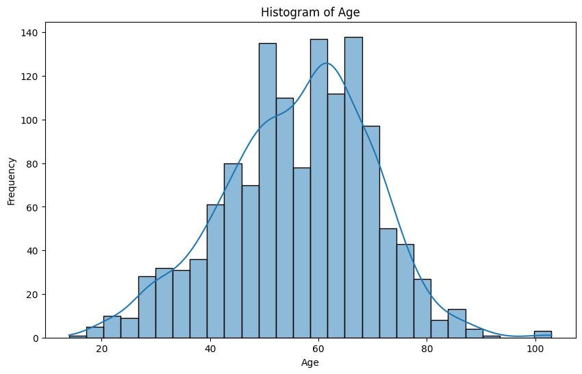

```python
# Histogram of Age
plt.figure(figsize=(10, 6))
sns.histplot(df['Age'], kde=True)
plt.title('Histogram of Age')
plt.xlabel('Age')
plt.ylabel('Frequency')
plt.show()
```

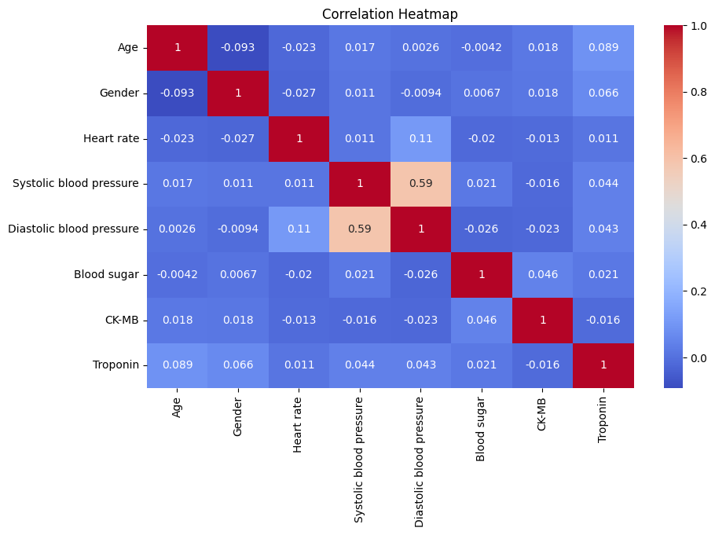

```python
# Correlation Heatmap
plt.figure(figsize=(10, 6))
sns.heatmap(df[features].corr(), annot=True, cmap='coolwarm')
plt.title('Correlation Heatmap')
plt.show()
```

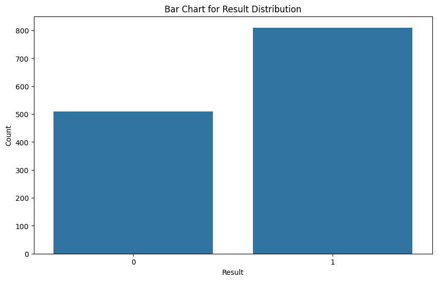

```python
# Bar Chart for Result Distribution
plt.figure(figsize=(10, 6))
sns.countplot(x='Result', data=df)
plt.title('Bar Chart for Result Distribution')
plt.xlabel('Result')
plt.ylabel('Count')
plt.show()
```

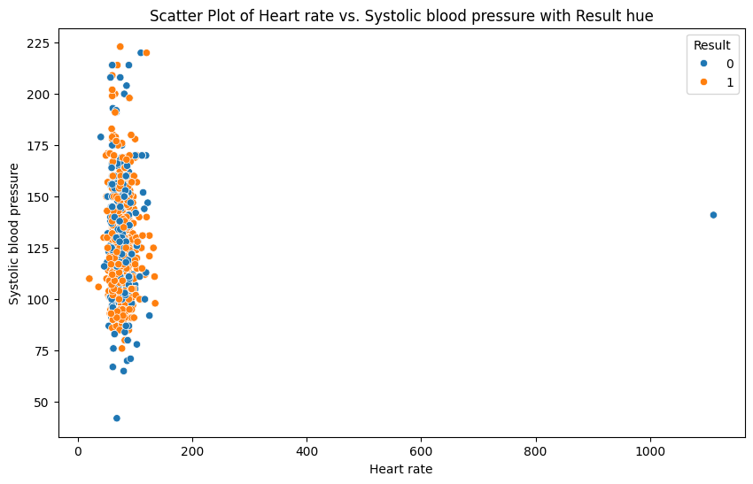

```python
# Scatter Plot of Heart rate vs. Systolic blood pressure with Result hue
plt.figure(figsize=(10, 6))
sns.scatterplot(x='Heart rate', y='Systolic blood pressure', hue='Result', data=df)
plt.title('Scatter Plot of Heart rate vs. Systolic blood pressure with Result hue')
plt.xlabel('Heart rate')
plt.ylabel('Systolic blood pressure')
plt.show()
```